# Layered Integration Approach for Multi-view Analysis of Real-world Datasets

## 3.3 Compare the difference of the parameters in the operating modes

In the cell below we plot for **one turbine** the distributions of each parameter for the clusters separately. This indicates what the main differences are between the operating modes.

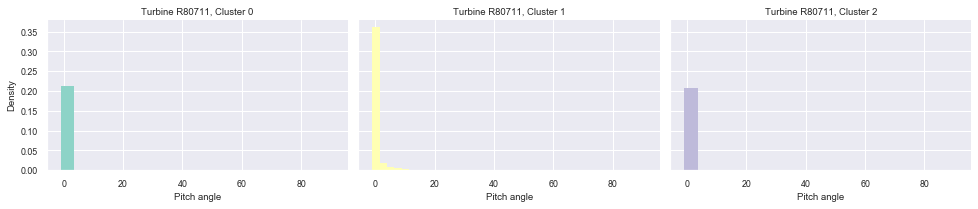

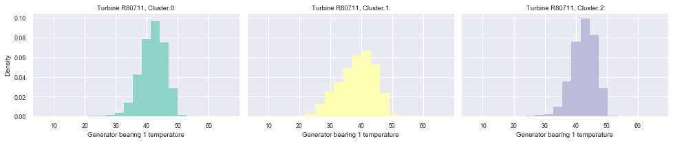

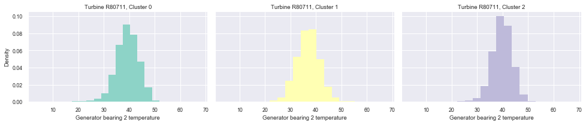

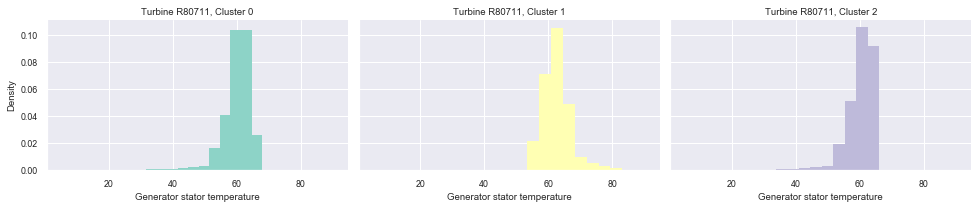

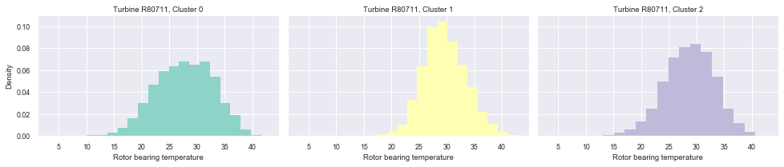

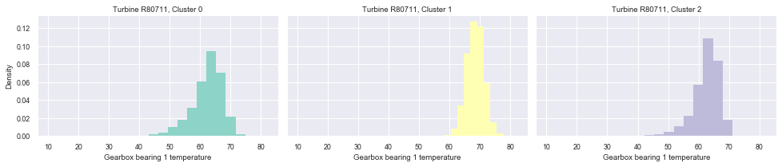

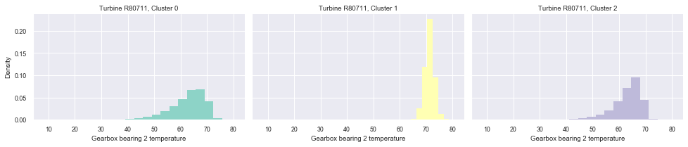

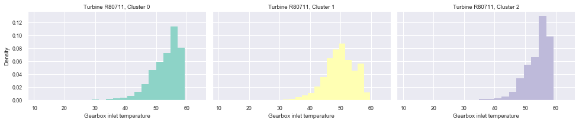

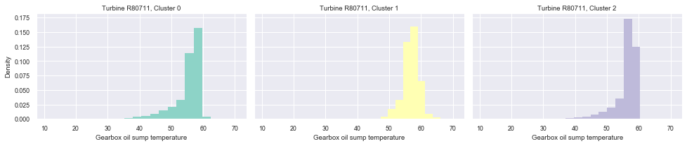

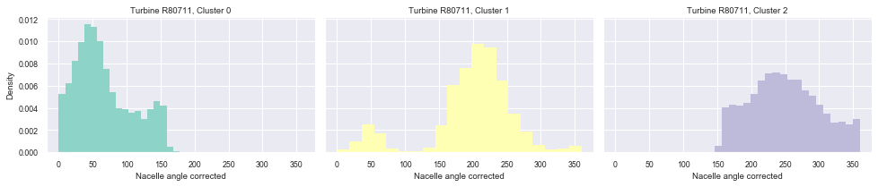

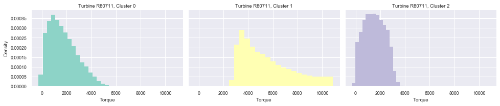

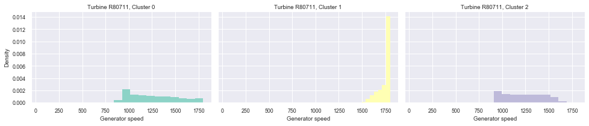

```python
# Select one turbine:
turbine_nr = 0 #Can be 0, 1, 2 or 3
turbine = turbines[turbine_nr]
df_One = dict_turbines[turbine]

color_index = sum(n_clusters[0:turbine_nr])
colors = colorpal[color_index:color_index+n_clusters[turbine_nr]]

for f, feature in enumerate(operational_features):
    g1 = sns.FacetGrid(df_One, col="Label", height=3, aspect = 1.5, hue='Label', palette=colors)
    g1.map(plt.hist, feature, linewidth=0, alpha=1, density=True, bins=20)
    g1.set_axis_labels(features_dict[feature], "Density")
    g1.set_titles("Turbine " + turbine + ", Cluster {col_name}")
```

Observations:

- Operating mode 1 differs mainly from the others in:
  - Generator stator temperature
  - Gearbox bearing 1 temperature
  - Gearbox bearing 2 temperature
  - Gearbox inlet temperature
  - Torque
- All operating modes differ clearly from the others in:
  - Nacelle angle corrected
  - Generator speed

## 3.4 Investigate the minimum and maximum value of each parameter in each cluster

Each cluster will define a range of allowable values for each operational parameter and thus generates parametric characterisation of the operating mode. In this way, the pool of clusters produced for the fleet leads to the construction of a repository of operating modes, each one characterized by two vectors of low and high values (see Table below). For each operating mode, the high and low ranges for each parameter in the operating mode can also be considered as allowable ranges for the corresponding parameter, provided the other parameters are within the other ranges specified for this mode.

```python
table = sf.create_table_endogenous_view(turbines, dict_turbines, operational_features)
table
```

|  |  | Turbine 1 OM1 | Turbine 1 OM2 | Turbine 1 OM3 | Turbine 2 OM4 | Turbine 2 OM5 | Turbine 2 OM6 | Turbine 2 OM7 | Turbine 3 OM8 | Turbine 3 OM9 | Turbine 3 OM10 | Turbine 3 OM11 | Turbine 4 OM12 | Turbine 4 OM13 | Turbine 4 OM14 |
| --- | --- | --- | --- | --- | --- | --- | --- | --- | --- | --- | --- | --- | --- | --- | --- |
| Ba_avg | min | -1 | -1 | -1 | -1 | -1 | -1 | -1 | -1 | -1 | -1 | -1 | -1 | -1 | -13 |
|  | max | 90 | 49 | 91 | 51 | 83 | 75 | 89 | 89 | 84 | 34 | 90 | 88 | 89 | 46 |
| Ds_avg | min | 6 | 7 | 6 | 16 | 27 | 28 | 6 | 24 | 25 | 13 | 4 | 5 | 6 | 14 |
|  | max | 65 | 67 | 65 | 66 | 68 | 65 | 52 | 65 | 64 | 67 | 53 | 63 | 67 | 63 |
| Db1t_avg | min | 6 | 6 | 4 | 6 | 23 | 24 | 2 | 23 | 19 | 8 | 2 | 4 | 2 | 9 |
|  | max | 63 | 68 | 65 | 59 | 57 | 58 | 58 | 60 | 57 | 60 | 52 | 58 | 62 | 62 |
| Db2t_avg | min | 55 | 932 | 39 | 973 | 165 | 168 | 46 | 25 | 108 | 1171 | 23 | 43 | 50 | 964 |
|  | max | 1800 | 1804 | 1778 | 1804 | 1800 | 1790 | 1753 | 1795 | 1800 | 1804 | 1720 | 1719 | 1800 | 1804 |
| Dst_avg | min | 5 | 16 | 5 | 21 | 37 | 36 | 4 | 38 | 35 | 19 | 1 | 1 | 4 | 22 |
|  | max | 71 | 91 | 77 | 95 | 75 | 86 | 73 | 84 | 74 | 94 | 73 | 77 | 69 | 88 |
| Gb1t_avg | min | 11 | 39 | 10 | 46 | 47 | 49 | 11 | 48 | 49 | 49 | 9 | 9 | 8 | 43 |
|  | max | 75 | 82 | 74 | 84 | 77 | 76 | 87 | 78 | 76 | 85 | 81 | 73 | 76 | 76 |
| Gb2t_avg | min | 9 | 39 | 8 | 48 | 47 | 47 | 10 | 47 | 49 | 48 | 8 | 7 | 8 | 48 |
|  | max | 76 | 81 | 75 | 80 | 75 | 74 | 72 | 75 | 75 | 77 | 70 | 73 | 75 | 77 |
| Git_avg | min | 13 | 23 | 11 | 21 | 27 | 36 | 12 | 35 | 32 | 28 | 11 | 11 | 12 | 27 |
|  | max | 59 | 64 | 59 | 61 | 60 | 60 | 57 | 59 | 59 | 59 | 57 | 59 | 59 | 59 |
| Gost_avg | min | 11 | 24 | 11 | 26 | 39 | 42 | 11 | 42 | 39 | 25 | 10 | 10 | 11 | 25 |
|  | max | 65 | 71 | 63 | 69 | 61 | 65 | 59 | 63 | 60 | 65 | 60 | 60 | 60 | 65 |
| Rbt_avg | min | 0 | 0 | 146 | 0 | 0 | 138 | 0 | 141 | 0 | 0 | 0 | 142 | 0 | 0 |
|  | max | 187 | 360 | 360 | 360 | 149 | 360 | 360 | 360 | 148 | 360 | 360 | 360 | 195 | 360 |
| Rm_avg | min | 5 | 6 | 3 | 6 | 12 | 13 | 1 | 13 | 13 | 7 | 2 | 0 | 2 | 7 |
|  | max | 42 | 43 | 43 | 41 | 40 | 41 | 37 | 54 | 54 | 53 | 49 | 46 | 44 | 46 |
| Na_c_avg | min | -270 | 2452 | -290 | 2248 | -411 | -348 | -337 | -223 | -221 | 2633 | -385 | -406 | -250 | 2399 |
|  | max | 6446 | 10876 | 5249 | 10876 | 6402 | 5084 | 7180 | 4626 | 6452 | 10875 | 6408 | 5655 | 6474 | 10875 |

# 4. LAYER 2: Mediation Analysis

In this layer, we pursue a way to derive an alternative representation of each operating mode in terms of expected performance. The richness of our multivariate data allows to consider an alternative view for each cluster of timestamps generated in the previous layer.

To do this, we first divide the solution space of each operating mode into hypercubes with the dimensions wind speed, wind direction and ambient temperature. Next, we calculate for each of the hypercubes the kernel density estimation (KDE) of the active power. And than finally, we obtain a profile for each operating mode by summing the weighted KDEs together and normalize them.

## 4.1 Divide the space into hypercubes

```python
# Creating an empty Dataframe
cluster_features = pd.DataFrame()

# Define the amount of splits per feature (for binning)
dict_features = {'Wa_c_avg': 6, 'Ws_avg':11, 'Ot_avg':6}
ref_vars = list(dict_features.keys())
target_var = ['P_avg']
dat_types = ['angular','numerical','numerical']

# Define cubes for all
_, cube_specs, _ = hypercubes.define_binning(dict_turbines[turbines[0]], ref_vars, dict_features)

# Give each hypercube an index number
cube_ids = sf.make_cube_ids(cube_specs, ref_vars)

for turbine in turbines:
    # Enricht dataframe with hypercube numbers
    dict_turbines[turbine],_ = hypercubes.define_cubes_in_df(dict_turbines[turbine].copy(), ref_vars, target_var[0], drop_stats=True, reset_idx=True,
                                       cube_specs=cube_specs, cube_ids=cube_ids, assign_nearest_cube=False,
                                       dat_types=dat_types)
```

Let us now remove all hypercubes cubes which contain less then 10 points. Since these hypercubes are so sparse, the features we will derive later on within those hypercubes would not be reliable.

In the plot below one can see the effect of this filtering. Each operating mode got rid of around 30% of the hypercubes, while almost all points are represented by their hypercube.

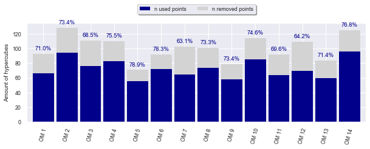

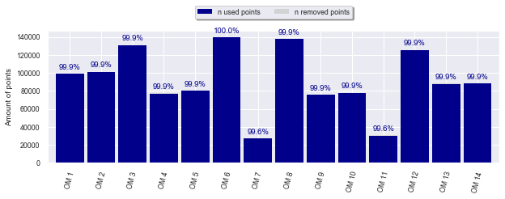

```python
MIN_POINTS_IN_CUBE = 10
df_cube_counts, cluster_labels = sf.visualize_sparse_hypercubes(MIN_POINTS_IN_CUBE, turbines, dict_turbines, n_clusters)
```

## 4.2 Calculate the kernel density estimations

Below, we estimate the density of the active power within each hypercube. This is estimated by the KDE approach where we use a Gaussian kernel and the Silverman rule of thumb to calculate the bandwidth.

```python
KDEs, points_per_cube = sf.calculate_KDE_per_hypercube(turbines, n_clusters, dict_turbines, MIN_POINTS_IN_CUBE)
```

## 4.3 Combine densities per cluster as an endogenous profile for each internal operating mode

Below, one can see all original KDEs on the left (per operating mode), and the constructed performance profile (mixture probability distribution) on the right. One already can observe different patterns between operating modes of the same wind turbine, and similar patterns between operating modes of different wind turbines.

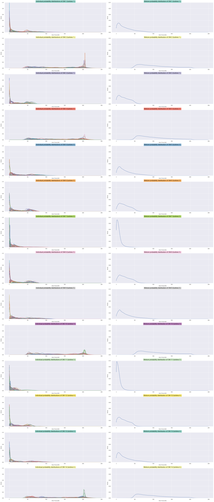

```python
sum_densities = sf.construct_engdogenous_profiles(turbines, n_clusters, points_per_cube, KDEs, colorpal)
```

## 4.4 Calculate the pairwise distance

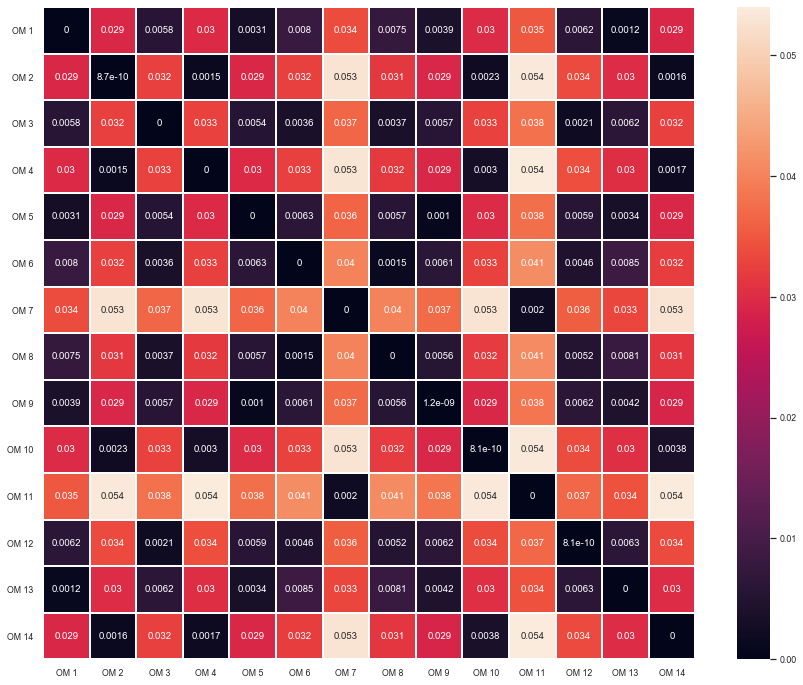

```python
# Calculate distance matrix
cluster_distances = pairwise_distances(sum_densities, metric='euclidean')

# Visualise heatmap
plt.figure(figsize = (15,12))
OM_labels = ['OM '+str(i) for i in list(range(1, sum(n_clusters)+1))]
sns.heatmap(cluster_distances, annot=True, linewidths=1, square=True, xticklabels=OM_labels, yticklabels=OM_labels)
plt.yticks(rotation=0);
```

# 5. LAYER 3: Integration Analysis

In this layer, we aim to combine the operational view (from Layer 1) with the exogenous view (from Layer 2). To do this, the obtained performance profiles (mixture distributions) per individual operating mode are pooled together and subjected to k-means clustering. This way we will obtain fleet-wide performance profiles, which we can trace back to the allowable ranges of turbine specific endogenous parameters (see the table which we constructed before).

## 5.1 Determine the appropriate amount of clusters

In here the optimal number of **fleet-wide** operating modes is investigated. We use again the Euclidean distance as distance measure. However, other measures as the Jensen Shannon distance might be used in future.

Following the majority voting system, the optimal amount of clusters (fleet-wide operating modes) is 3.

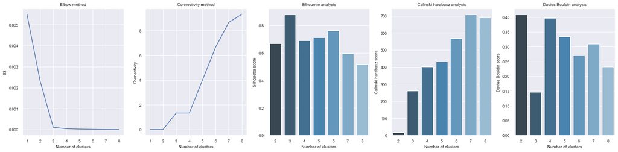

```python
sf.plot_kmeans_validation(sum_densities)
```

### 5.2 Cluster the operating modes into fleet-wide operating modes, based on their individual performance profile

We do this again with k-means clustering. From the previous cell we know that k=3.

```python
n_reduced_clusters = 3

# Do clustering:
kmeans = KMeans(n_reduced_clusters, init='k-means++', max_iter=300, n_init=10, random_state=0)
final_labels = kmeans.fit_predict(sum_densities) # Only use the operational features in the MAP step

# Map fleet-wide labels to letters:
OM_dict = dict({0:'A', 1:'B', 2:'C', 3:'C', 4:'C', 5:'D'})
final_labels = [OM_dict[label] for label in final_labels]

dictionary = dict(zip(df_cube_counts['cluster'], final_labels))
```

#### Show the power curve and torque curve for each of the fleet-wide operating modes

As we can see on the plots below, each operating mode are clearly different in the two curves.

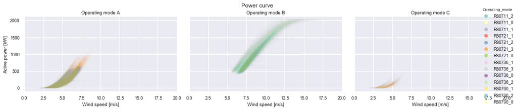

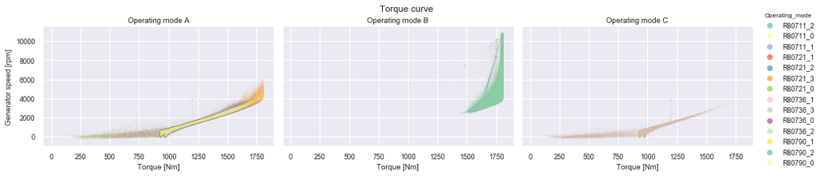

```python
# Make one big dataframe with the fleet-wide operating mode labels in it
cluster_centers_reduced = pd.concat(dict_turbines, ignore_index=True)
cluster_centers_reduced["Operating_mode"] = cluster_centers_reduced.Wind_turbine_name + '_' + cluster_centers_reduced.Label.astype(str)
cluster_centers_reduced["FW_Operating_mode"] = cluster_centers_reduced["Operating_mode"].replace(dictionary)

# Plot the points within each cluster
sf.plot_power_and_torque(cluster_centers_reduced, colorpal)
```

### Show the points of the fleet-wide operating modes PER TURBINE

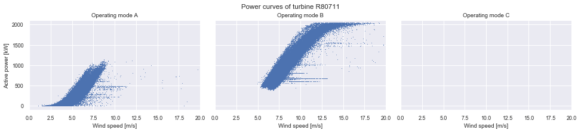

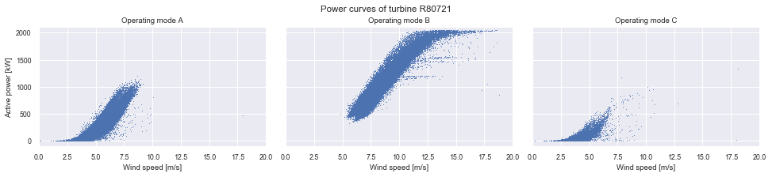

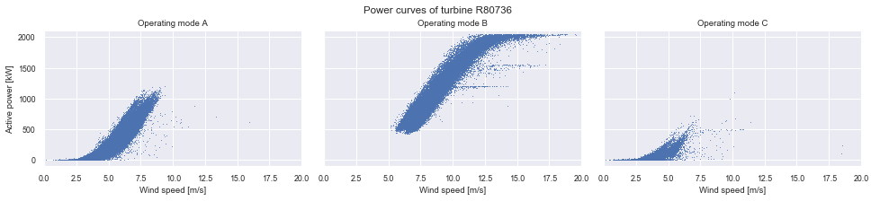

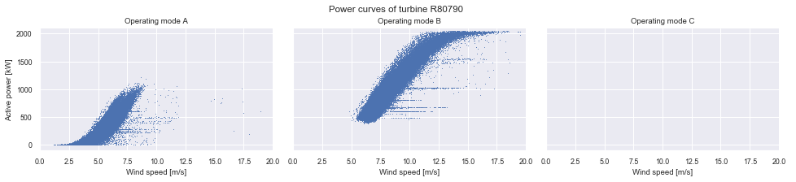

```python
for name, dataset in dict_turbines.items():

    dataset["Operating_mode"] = dataset.Wind_turbine_name + '_' + dataset.Label.astype(str)
    dataset["FW_Operating_mode"] = dataset["Operating_mode"].replace(dictionary)

    # 1. Plot power curve
    g1 = sns.FacetGrid(dataset, col="FW_Operating_mode", height=3, aspect = 1.5, col_order=['A','B','C'])
    g1.map(plt.scatter, "Ws_avg", "P_avg", s=1,linewidth=0, alpha = 1)
    g1.set(xlim=(0, 20), ylim=(-100, 2100))
    g1.set_axis_labels( "Wind speed [m/s]", "Active power [kW]")
    g1.set_titles("Operating mode {col_name}")
    g1.fig.suptitle('Power curves of turbine '+name, y=1.02)
    g1.add_legend()
    for lh in g1._legend.legendHandles: # This makes the legend visible
        lh.set_alpha(1)
        lh._sizes = [50]
    plt.tight_layout()
```

## 5.3 Calculate **fleet-wide** performance profiles of each fleet-wide operating mode

Now we calculate the **fleet-wide** performance profiles by summing the individual probabilistic distributions of each operating mode. The mixture weights have been computed as the number of points in the corresponding cluster from layer 1, normalized by the total number of points in the given fleet-wide cluster. The resulting very distinctive fleet-wide performance profiles denoted as A, B and C are depicted below.

*Remark: This is very similar as in the previous layer, but one level higher.*

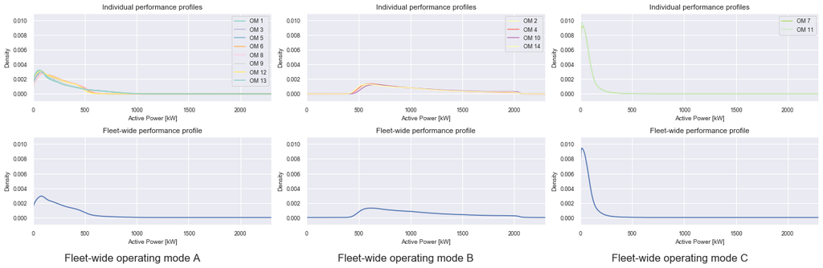

```python
sf.construct_fleetwide_performance_profiles(n_reduced_clusters, final_labels, sum_densities, df_cube_counts, points_per_cube, colorpal)
```

Now each of the fleet-wide performance profiles can be traced back to a subset of individual operating modes (this Table), resulting in fleet-wide (composite) operating modes, which we also denote with A, B and C: A={1,3,5,6,8,9,12,13}; B={2,4,10,14}; C ={7,11}. It is interesting to observe that the composite operating mode linked to profile C can be traced back to only two of the four wind turbines. The derived fleet-wide (composite) operating modes, each associated with a very distinctive performance profile (see Figure above), can now be used to label the fleet data as follows:

1. For each timestamp, consider the values of the 12 operational parameters.
2. Determine to which operating mode they can be assigned (see this Table). This is different per wind turbine.
3. Identify the fleet-wide (composite) operating mode to which the identified mode belongs.
4. Subsequently, assign the corresponding letter A, B, C or D (not seen) to the timestamp.

In this way, each dataset per turbine can be converted into A, B, C or D code (as a DNA sequence), which can be very insightful for monitoring purposes (e.g. long periods of B would signify optimal performance), but is also a powerful representation enabling more advanced applications, e.g.:

- mining the fleet data for interesting patterns such as transitions between operating modes
- zooming in periods with too many Ds
- training a predictor of expected production on historical data to be used to detect deviations during real-time operations.

# 6. Conclusion and future work

We have proposed a novel data analysis approach that can be used for multi-view analysis and integration of heterogeneous real-world datasets originating from multiple sources. The validity and the potential of the proposed approach has been demonstrated on a real-world dataset of a fleet of wind turbines. The obtained results are very encouraging. The method is very efficient and robust in detecting characteristic operating modes across the fleet. Subsequently, distinctive performance profiles are derived and associated with each operating mode, which enable converting the fleet data into powerful letter code suitable for more advanced mining.

For future work, we are interested to extend our research in the following directions:

1. Fine tune further the method by using e.g. an adaptive hypercube binning.
2. Testing different experimental scenarios e.g. comparing different time periods from the same wind turbine.
3. Consider additional validation use cases dealing with multi-source datasets e.g. mobility or manufacturing data.
4. Extend further the method by exploiting the possibility to covert the fleet data into letter code.